# LDA_QDA_Assignment 5

Shritama Sengupta (22MSD7032)

2023-11-19

## LDA

```r
# Display the first few rows of the dataset
head(mtcars)
```

```
##                    mpg cyl disp  hp drat    wt  qsec vs am gear carb
## Mazda RX4         21.0   6  160 110 3.90 2.620 16.46  0  1    4    4
## Mazda RX4 Wag     21.0   6  160 110 3.90 2.875 17.02  0  1    4    4
## Datsun 710        22.8   4  108  93 3.85 2.320 18.61  1  1    4    1
## Hornet 4 Drive    21.4   6  258 110 3.08 3.215 19.44  1  0    3    1
## Hornet Sportabout 18.7   8  360 175 3.15 3.440 17.02  0  0    3    2
## Valiant           18.1   6  225 105 2.76 3.460 20.22  1  0    3    1
```

```r
# Dimensions of the dataset
dim(mtcars)
```

```
## [1] 32 11
```

```r
# Split the data into training and testing sets
s_mtcars = sample(2, nrow(mtcars), replace = TRUE, prob = c(0.6, 0.4))
tr_mtcars = mtcars[s_mtcars == 1, ]
tt_mtcars = mtcars[s_mtcars == 2, ]
```

```r
# Dimensions of the training and testing sets
dim(tr_mtcars)
```

```
## [1] 23 11
```

```r
dim(tt_mtcars)
```

```
## [1]  9 11
```

```r
# Load necessary libraries
library(klaR)
```

```r
library(ggordiplots)
# Fit LDA model
lda_mtcars = lda(factor(cyl) ~ ., data = tr_mtcars)
```

```r
# Display summary of the LDA model
lda_mtcars
```

```
## Call:
## lda(factor(cyl) ~ ., data = tr_mtcars)
##
## Prior probabilities of groups:
##         4         6         8
## 0.3913043 0.1739130 0.4347826
##
## Group means:
##      mpg     disp        hp     drat       wt     qsec        vs        am
## 4 26.600 106.4111  82.88889 4.111111 2.275333 19.00333 0.8888889 0.7777778
## 6 19.475 178.1500 112.00000 3.620000 3.098750 18.15000 0.5000000 0.5000000
## 8 15.020 351.6600 201.00000 3.148000 3.983400 16.96500 0.0000000 0.1000000
##       gear     carb
## 4 4.222222 1.666667
## 6 3.750000 3.250000
## 8 3.200000 3.400000
##
## Coefficients of linear discriminants:
##              LD1          LD2
## mpg  -0.01608856  0.207120141
## disp  0.01741764 -0.001218825
## hp    0.01871843  0.048627341
## drat -2.98009291  2.211375358
## wt   -3.53965230  1.582705673
## qsec -0.21754074  0.112549285
## vs   -3.11507402 -0.869297118
## am   -2.50988973 -0.252755390
## gear -4.80571026  1.178062208
## carb  1.79938342 -1.879814375
##
## Proportion of trace:
##   LD1   LD2
## 0.976 0.024
```

### Prior Probabilities of Groups:

### 4, 6, 8: These are the levels of the response variable “cyl” (cylinders) in the “mtcars” dataset.

### Prior probabilities: The estimated proportions of each cylinder group in the training set.

### Group Means:

### mpg, disp, hp, … carb: These are the variables in the dataset.

### Group means: The average values of each variable for each cylinder group.

### Coefficients of Linear Discriminants:

### LD1, LD2: These are the linear discriminant functions.

### Coefficients: The weights assigned to each variable in the linear combination to form the discriminant functions.

### Proportion of Trace:

### LD1, LD2: The proportion of the total variability (trace) explained by each discriminant function.

### Interpretation:

### The model uses linear combinations of the input variables (mpg, disp, hp, etc.) to create discriminant functions (LD1 and LD2) that maximize the separation between the cylinder groups (4, 6, 8).

### The coefficients of the discriminant functions indicate the contribution of each variable to the separation between groups.

### The proportion of trace provides information about the relative importance of each discriminant function.

### In short, the LDA model has identified linear combinations of variables that effectively separate cars with different numbers of cylinders. The coefficients in the discriminant functions indicate the influence of each variable, and the proportion of trace helps assess the importance of each discriminant function in explaining the overall variability.

## QDA

```r
# Make predictions on the training set
pr_mtcars_train = predict(lda_mtcars, data = tr_mtcars)
```

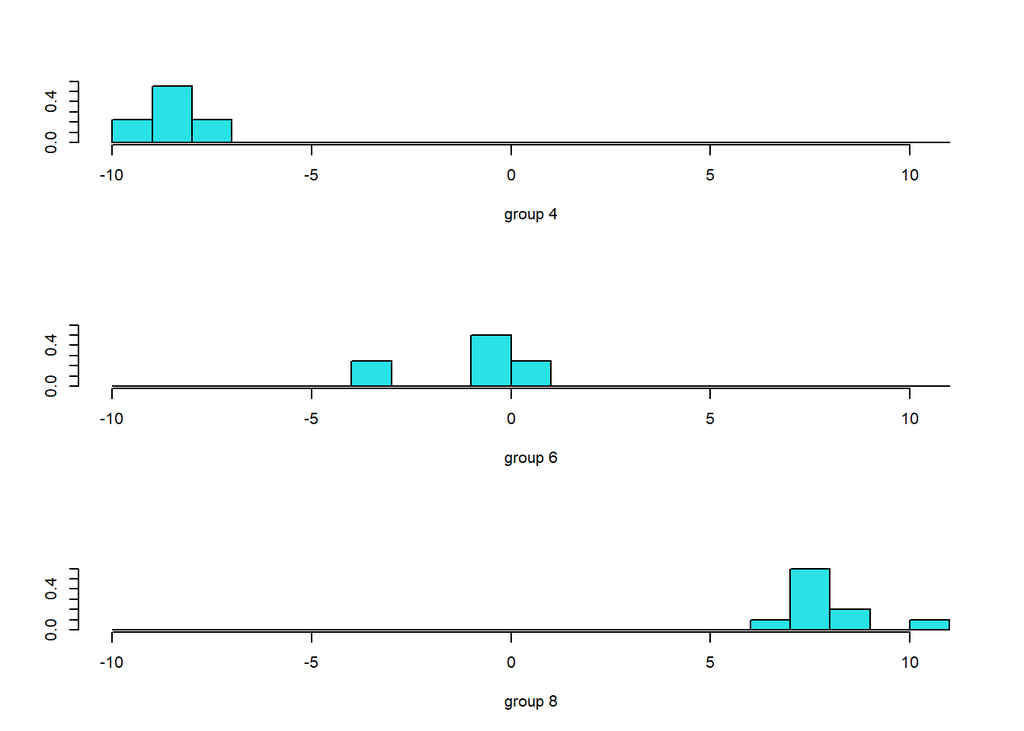

```r
# Evaluate on the training set
ldahist(pr_mtcars_train$x[, 1], g = tr_mtcars$cyl)
```

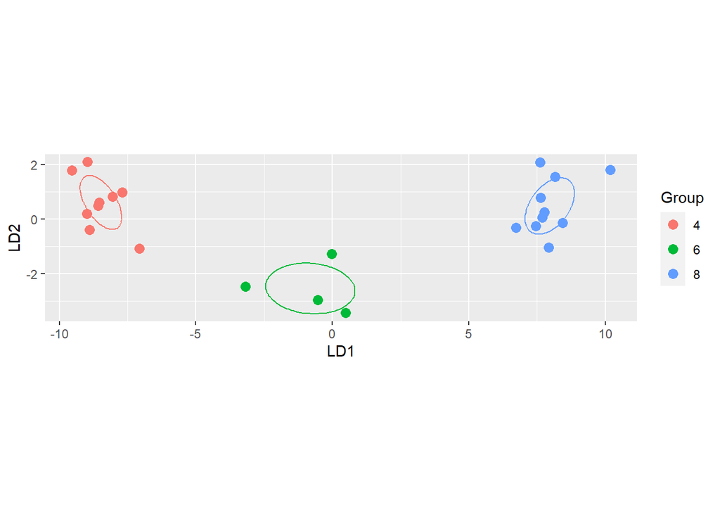

```r
gg_ordiplot(lda_mtcars, tr_mtcars$cyl)
```

```r
# Confusion table and accuracy on the training set
tab_train = table(pr_mtcars_train$class, tr_mtcars$cyl)
accuracy_train = sum(diag(tab_train)) / sum(tab_train)
accuracy_train
```

```
## [1] 1
```

```r
# Make predictions on the testing set
pr_mtcars_test = predict(lda_mtcars, newdata = tt_mtcars)
```

```r
# Confusion table and accuracy on the testing set
tab_test = table(pr_mtcars_test$class, tt_mtcars$cyl)
accuracy_test = sum(diag(tab_test)) / sum(tab_test)
accuracy_test
```

```
## [1] 0.7777778
```

```r
# Length of predicted classes and actual classes in the testing set
length(pr_mtcars_test$class)
```

```
## [1] 9
```

```r
length(tt_mtcars$cyl)
```

```
## [1] 9
```

```r
# Display the confusion table for the testing set
tab_test
```

```
##
##     4 6 8
##   4 1 0 0
##   6 1 3 1
##   8 0 0 3
```

```r
# Load the necessary libraries
library(klaR)
library(ggordiplots)

# Split the data into training and testing sets
set.seed(123)  # Set seed for reproducibility
s_iris = sample(2, nrow(iris), replace = TRUE, prob = c(0.6, 0.4))
tr_iris = iris[s_iris == 1, ]
tt_iris = iris[s_iris == 2, ]

# Fit QDA model on the training set
qda_iris = qda(Species ~ ., data = tr_iris)

# Display summary of the QDA model
qda_iris
```

```
## Call:
## qda(Species ~ ., data = tr_iris)
##
## Prior probabilities of groups:
##     setosa versicolor  virginica
##  0.3370787  0.3370787  0.3258427
##
## Group means:
##            Sepal.Length Sepal.Width Petal.Length Petal.Width
## setosa         4.946667    3.380000     1.443333    0.250000
## versicolor     5.943333    2.803333     4.240000    1.316667
## virginica      6.527586    2.920690     5.489655    2.048276
```

### Prior Probabilities of Groups:

### setosa, versicolor, virginica: These are the levels of the response variable “Species” in the “tr_iris” dataset.

### Prior probabilities: The estimated probabilities of each species group in the training set.

### Group Means:

### Sepal.Length, Sepal.Width, Petal.Length, Petal.Width: These are the variables in the dataset.

### Group means: The average values of each variable for each species group.

### Interpretation in Short:

### The QDA model has estimated the prior probabilities for each species group, indicating the relative prevalence of setosa, versicolor, and virginica in the training set.

### The group means provide insights into the average values of the four features (Sepal.Length, Sepal.Width, Petal.Length, Petal.Width) for each species group.

### QDA aims to find quadratic decision boundaries that maximize the separation between the species groups based on these features.

### In short, the model is trained to discriminate between different species of iris flowers using a quadratic approach. The prior probabilities and group means provide information about the distribution of the species groups and the average feature values for each group in the training data.

```r
# Make predictions on the testing set using QDA
pr_qda_iris = predict(qda_iris, newdata = tt_iris)

# Confusion table and accuracy on the testing set for QDA
tab_qda_iris = table(pr_qda_iris$class, tt_iris$Species)
accuracy_qda_iris = sum(diag(tab_qda_iris)) / sum(tab_qda_iris)
accuracy_qda_iris
```

```
## [1] 0.9016393
```

```r
# Length of predicted classes and actual classes in the testing set for QDA
length(pr_qda_iris$class)
```

```
## [1] 61
```

```r
length(tt_iris$Species)
```

```
## [1] 61
```

```r
# Display the confusion table for the testing set for QDA
tab_qda_iris
```

```
##
##              setosa versicolor virginica
##   setosa         20          0         0
##   versicolor      0         16         2
##   virginica       0          4        19
```